# Golem

## Przygotowanie stanowiska pracy

- [Program R](https://www.r-project.org/)
- [RStudio](https://www.rstudio.com/)
- [Materiały](https://github.com/awerroes/repetytorium)

## On-line

- [Github](https://github.com/)
- [Etherpad](https://ethercalc.org/)
- [EtherCalc](https://ethercalc.org/)

## Golem

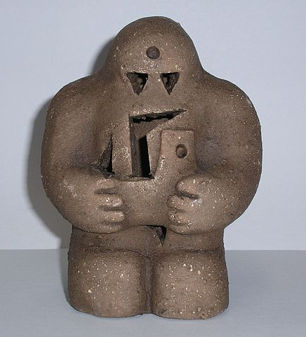

Metoda naukowa

## Mapa

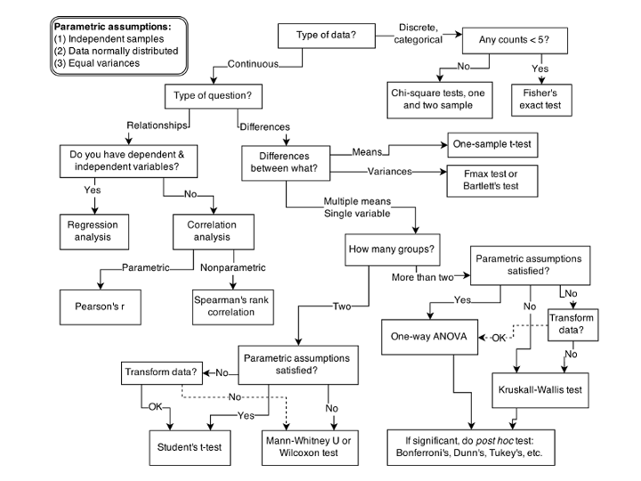

Labirynt

## Sposoby przedstawiania danych

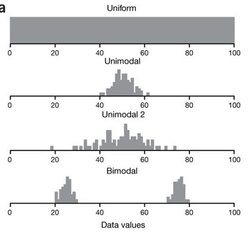

Wykresy

## Sposoby przedstawiania danych

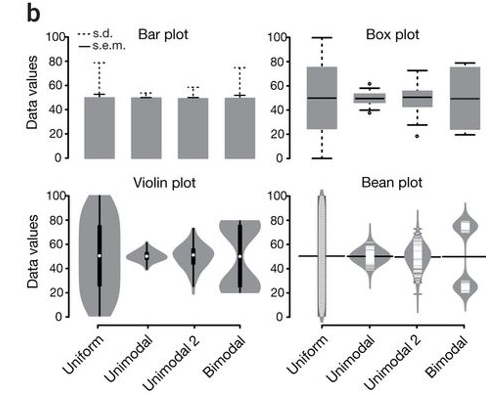

Wykresy

## Gramatyka grafiki - ggplot2

```r
library(ggplot2)
library(PBImisc)

ggplot(data = genomes) + geom_point(aes(x=temperature, y=size))
```

## Gramatyka grafiki - ggplot2

```r
library(ggplot2)
library(PBImisc)

ggplot(data = genomes) + geom_point(aes(x=temperature, y=size)) +
  geom_smooth(aes(x=temperature, y=size), method = 'lm')
```

## Gramatyka grafiki - ggplot2

```r
library(ggplot2)
library(PBImisc)

ggplot(data = genomes) + geom_point(aes(x=temperature, y=size)) +
  geom_smooth(aes(x=temperature, y=size), method = 'loess')
```

## Gramatyka grafiki - ggplot2

```r
library(ggplot2)
library(PBImisc)

ggplot(data = genomes) + geom_point(aes(x=temperature, y=size)) +
  geom_smooth(aes(x=temperature, y=size), method = 'loess') +
  xlab("Temperatura środowiska") +
  ylab("Wielkość genomu [Mpz]")
```

## Gramatyka grafiki - ggplot2

```r
library(ggplot2)
library(PBImisc)

ggplot(data = genomes) + geom_point(aes(x=temperature, y=size)) +
  geom_smooth(aes(x=temperature, y=size), method = 'loess') +
  xlab("Temperatura środowiska") +
  ylab("Wielkość genomu [Mpz]") +
  ggtitle("Zależność wielkości genomu od temperatury środowiska") +
  theme_bw()
```

## Gramatyka grafiki - ggplot2

```r
library(ggplot2)
library(PBImisc)

ggplot(data = genomes) + geom_boxplot(aes(x=habitat, y=temperature)) +
  xlab("Temperatura środowiska") +
  ylab("Wielkość genomu [Mpz]")
```

## Gramatyka grafiki - ggplot2

```r
library(ggplot2)
library(PBImisc)

ggplot(data = genomes) + geom_boxplot(aes(x=habitat, y=temperature)) +
  geom_jitter(aes(x=habitat, y=temperature)) +
  xlab("Temperatura środowiska") +
  ylab("Wielkość genomu [Mpz]")
```

## Gramatyka grafiki - ggplot2

```r
library(ggplot2)
library(PBImisc)

ggplot(data = genomes) + geom_boxplot(aes(x=habitat, y=temperature)) +
  geom_jitter(aes(x=habitat, y=temperature, color = temp.group)) +
  xlab("Temperatura środowiska") +
  ylab("Wielkość genomu [Mpz]") +
  theme_bw()
```

## [r4photobiology](https://www.r4photobiology.info/)

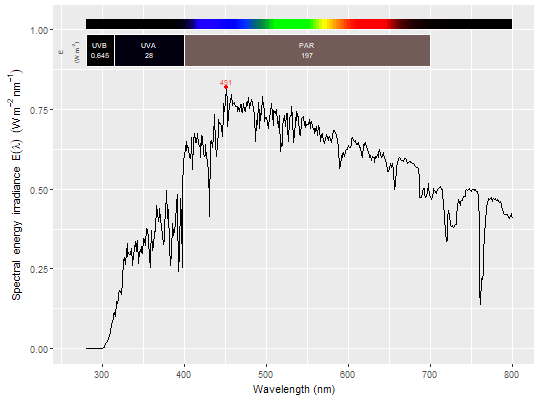

Quantification of ultraviolet and visible radiation for photobiology

## Bioconductor

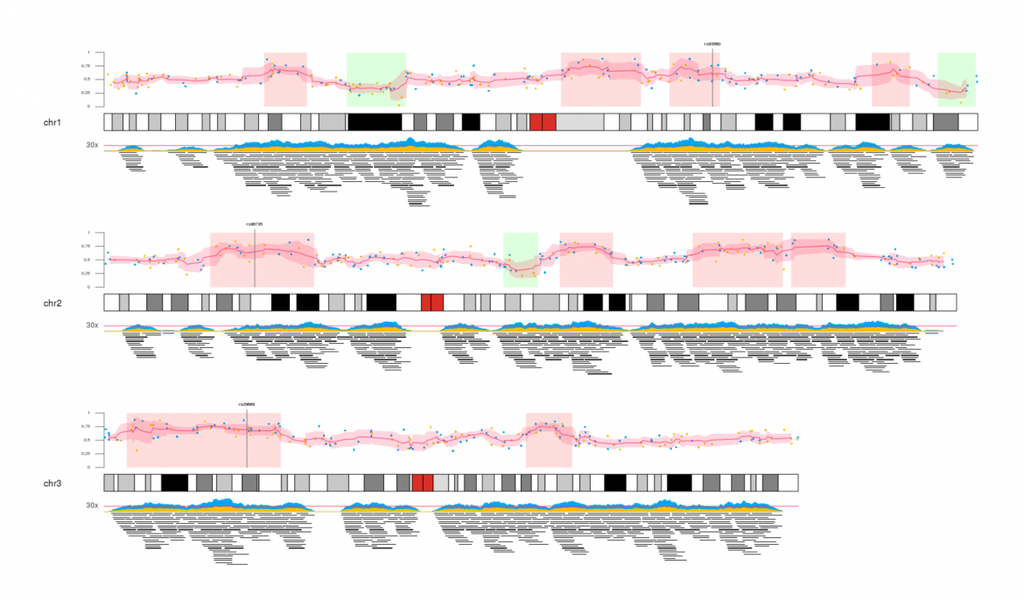

karyoploteR

## Materiały

- [ggplot2-tidyverse](https://ggplot2.tidyverse.org/)
- [Cheat Sheets](https://github.com/rstudio/cheatsheets/blob/master/data-visualization-2.1.pdf)
- [Rozszerzenia](http://www.ggplot2-exts.org/gallery/)
- [GUI](https://github.com/gertstulp/ggplotgui)
- [Przykłady zastosowania](https://bit.ly/2MqmL1A)
- [Oficjalna dokumentacja](https://ggplot2.tidyverse.org/)
- [R for data science](https://r4ds.had.co.nz/)
- [R graphics cookbook](http://www.cookbook-r.com/Graphs/)
- [Java Script - **Data-Driven Documents** - d3.js](https://github.com/d3/d3/wiki/Gallery)

## Mapa

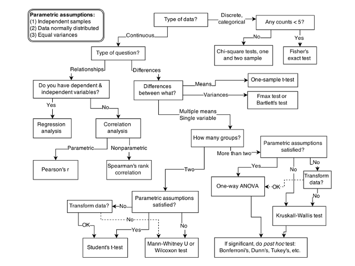

Labirynt

## Testy parametryczne i nie

- niezależność
- rozkład normalny
- podobna wariancja (zmienność)

## Rozkład normalny (Gaussa)

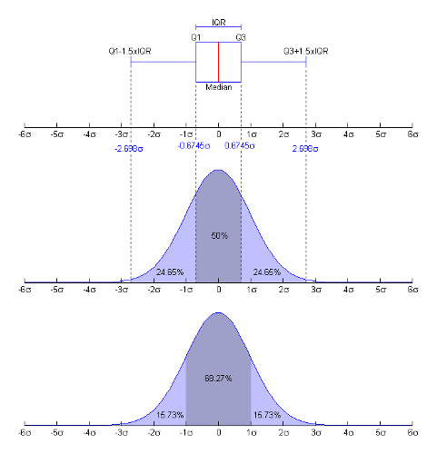

## Inne rozkłady (ciągłe, dyskretne)

- jednostajny
- Bernoulliego
- Poissona
- studenta
- \(\chi^2\)
- …

## Test normalności QQnorm

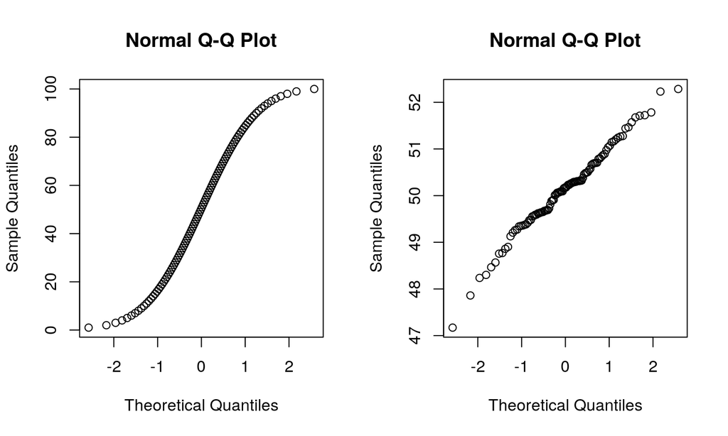

```r
jednostajny = seq(1:100)
normalny = rnorm(100, mean = 50, sd = 1)
par(mfrow=c(1,2))
qqnorm(jednostajny)
qqnorm(normalny)
```

## Test Shapiro - Wilka

```r
jednostajny = seq(1:100)
shapiro.test(jednostajny)
```

```
##
##  Shapiro-Wilk normality test
##
## data:  jednostajny
## W = 0.95472, p-value = 0.001722
```

## Test Shapiro - Wilka

```r
normalny = rnorm(100, mean = 50, sd = 1)
shapiro.test(normalny)
```

```
##
##  Shapiro-Wilk normality test
##
## data:  normalny
## W = 0.98052, p-value = 0.1458
```

## Podobna wariancja - wykresy

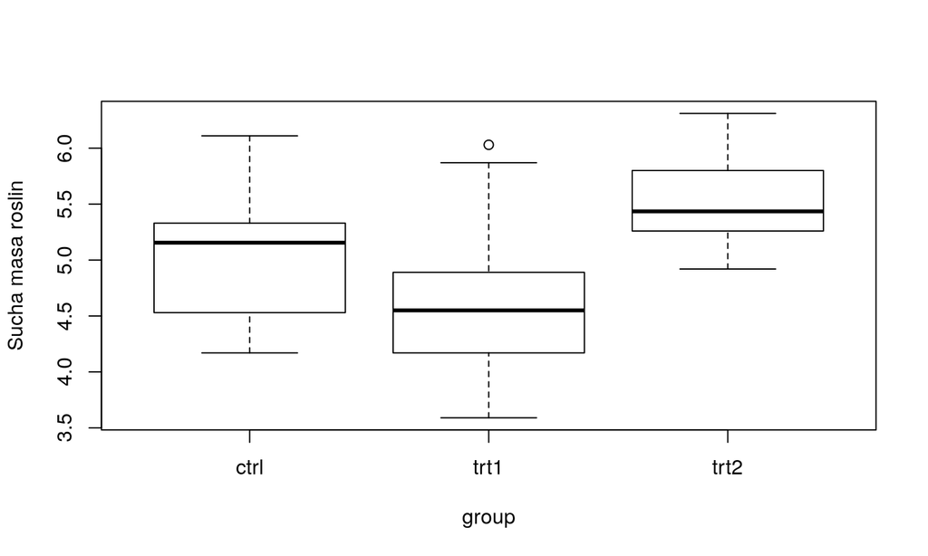

```r
data("PlantGrowth")

boxplot(weight ~ group, data = PlantGrowth,
        ylab = "Sucha masa roslin")
```

## Podobna wariancja - **Test Bartletta**

```r
data("PlantGrowth")

bartlett.test(weight ~ group, data = PlantGrowth)
```

```
##
##  Bartlett test of homogeneity of variances
##
## data:  weight by group
## Bartlett's K-squared = 2.8786, df = 2, p-value = 0.2371
```

## Mapa

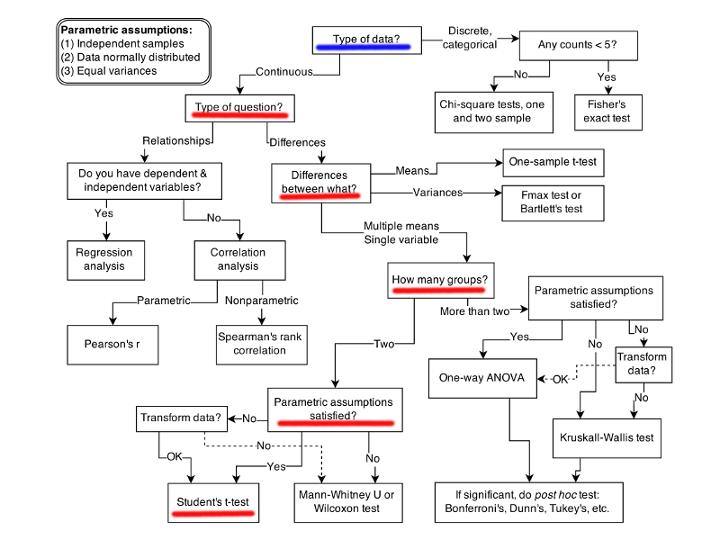

Labirynt

## Eksperyment 1

- Porównujemy **2** hodowle *A. thaliana* rosnące przy niskim lub wysokim natężeniu światła przez 21 dni.
- Po upływie 3 tygodni zbieramy liście, ekstrahujemy barwniki i porówujemy zawartość chlorofilu całkowitego.
- Czy warunki oświetlenia mają wpływ na zawartość chlorofili w liściach ?

## Hipoteza zerowa

- \(H_{0}: brak \ istotnych \ różnic \ pomiędzy \ średnimi\)
- Test t (Studenta)

\(\ t=\frac{\overline{x}_{1}-\overline{x}_{2}}{\sqrt{\frac{S_{1}^{2}}{n_{1}}+\frac{S_{2}^{2}}{n_{1}}}}\)

- Jeżeli wartość **t** jest większa od wartości krytycznej odczytanej z tablic odrzucamy \(H_{0}\)!

## Jak to policzyć?

\(\ t=\frac{\overline{x}_{LL}-\overline{x}_{HL}}{\sqrt{\frac{S_{LL}^{2}}{n_{LL}}+\frac{S_{HL}^{2}}{n_{HL}}}}\)

\(\ \overline{x}_{LL}\) - średnia zawartość chlorofilu w warunkach LL

\(\ S_{LL}\) - odchylenie standardowe zawartości chlorofilu w warunkach LL

\(\ n_{LL}\) - liczebność roślin w warunkach LL

```r
t.test(LL, HL)
```

## Laboratorium 2A

1. Przypisz 2 grupom roślin HL i LL zawartości chlorofili

```r
HL = c(8.2, 6.5, 9, 8.7, 8.13)
LL = c(10.5, 9.5, 10, 7.91, 9.2)
```

## Laboratorium 2B

1. Narysuj wykres porównujący grupy

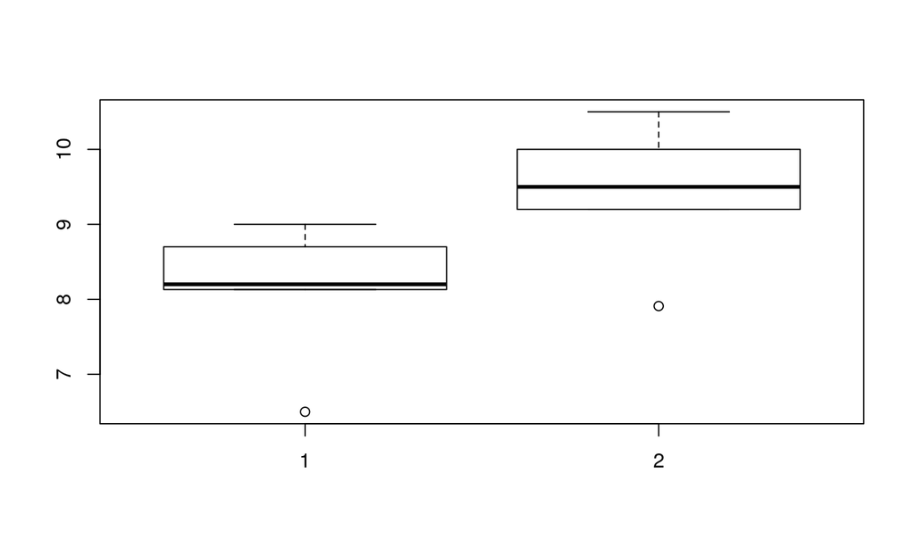

```r
boxplot(HL, LL)
```

## Laboratorium 2C

1. Sprawdź testem t czy masz rację

```r
t.test(HL, LL)
```

```
##
##  Welch Two Sample t-test
##
## data:  HL and LL
## t = -2.1379, df = 7.9987, p-value = 0.065
## alternative hypothesis: true difference in means is not equal to 0
## 95 percent confidence interval:
##  -2.7355354  0.1035354
## sample estimates:
## mean of x mean of y
##     8.106     9.422
```

## Eksperyment \(\mu\)

```r
set.seed(1234)
dat <- data.frame(cond = factor(rep(c("A","B"), each=200)),
                  rating = c(rnorm(200),rnorm(200, mean=.8)))
```

## Eksperyment \(\mu\)

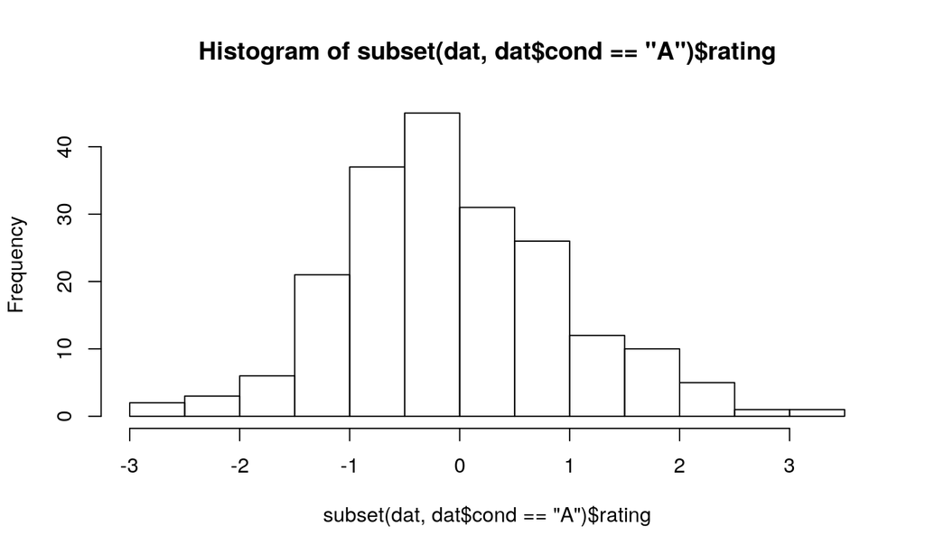

```r
hist(subset(dat, dat$cond=="A")$rating)
```

## Eksperyment \(\mu\)

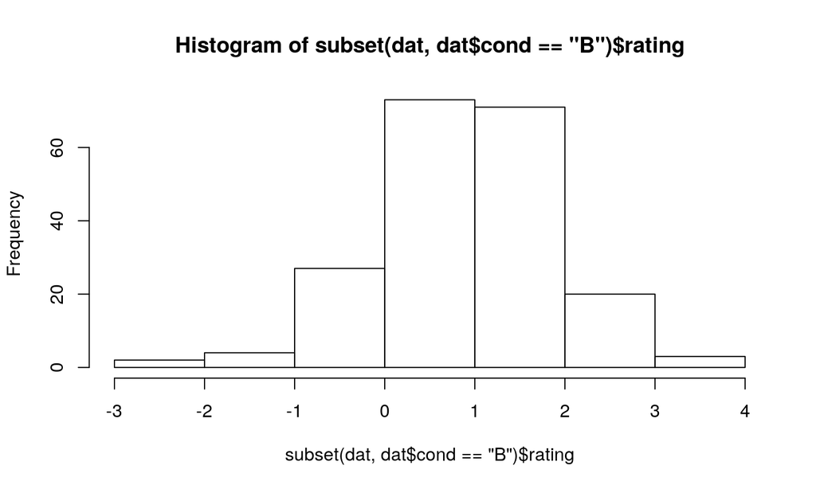

```r
hist(subset(dat, dat$cond=="B")$rating)
```

## Eksperyment \(\mu\)

```r
a = sample(subset(dat, dat$cond == "A")$rating, 3)
b = sample(subset(dat, dat$cond == "B")$rating, 3)

t.test(a, b)
```

```
##
##  Welch Two Sample t-test
##
## data:  a and b
## t = -0.216, df = 2.5562, p-value = 0.845
## alternative hypothesis: true difference in means is not equal to 0
## 95 percent confidence interval:
##  -5.336276  4.719061
## sample estimates:
## mean of x mean of y
## 0.4207416 0.7293491
```

## Eksperyment \(\mu\)

```r
a = sample(subset(dat, dat$cond == "A")$rating, 3)
b = sample(subset(dat, dat$cond == "B")$rating, 3)

t.test(a, b)
```

```
##
##  Welch Two Sample t-test
##
## data:  a and b
## t = -1.5844, df = 2.822, p-value = 0.2169
## alternative hypothesis: true difference in means is not equal to 0
## 95 percent confidence interval:
##  -3.341895  1.173371
## sample estimates:
## mean of x mean of y
##  1.122729  2.206991
```

## Eksperyment \(\mu\)

```r
a = sample(subset(dat, dat$cond == "A")$rating, 3)
b = sample(subset(dat, dat$cond == "B")$rating, 3)

t.test(a, b)
```

```
##
##  Welch Two Sample t-test
##
## data:  a and b
## t = -2.2632, df = 3.7663, p-value = 0.09051
## alternative hypothesis: true difference in means is not equal to 0
## 95 percent confidence interval:
##  -2.9881229  0.3406797
## sample estimates:
##  mean of x  mean of y
## -0.1738133  1.1499083
```

## Fortuna

- tworzymy populację o średniej *mi1* i odchyleniu standardowym *si1*
- tworzymy populację o średniej *mi2* i odchyleniu standardowym *si2*
- z każdej populacji losujemy po kilka (*NP*) próbek
- sprawdzamy czy populacje są istotnie różne testem t
- *procedurę losowania i testowania powtarzamy 1000 razy*

```r
pval <- function(NP=3, mi1=0, mi2=1, si1=1, si2=1)
{
  a = rnorm(NP, mi1, si1)
  b = rnorm(NP, mi2, si2)
  t = t.test(a, b)
  t$p.value
}
```

## \(\ \frac{\mu_1 - \mu_2}{\sigma} \ ( \Delta \mu = 0.5, \ \sigma_1 = \sigma_2 = 1)\)

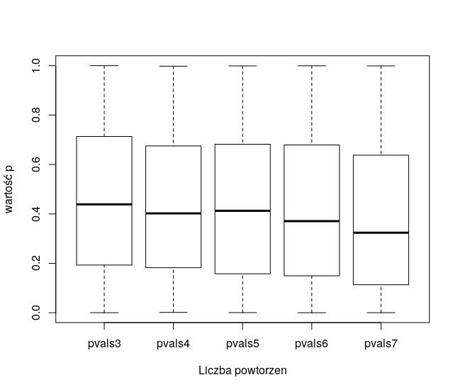

Wyniki 1

## \(\ \frac{\mu_1 - \mu_2}{\sigma} \ ( \Delta \mu = 1, \ \sigma_1 = \sigma_2 = 1)\)

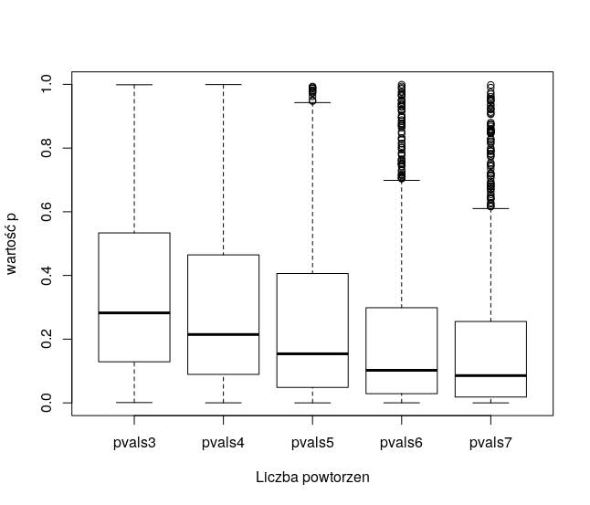

Wyniki 2

## \(\ \frac{\mu_1 - \mu_2}{\sigma} \ ( \Delta \mu = 2, \ \sigma_1 = \sigma_2 = 1)\)

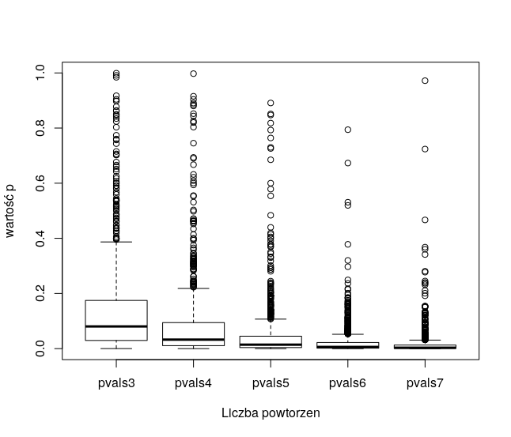

Wyniki 3

## \(\ \frac{\mu_1 - \mu_2}{\sigma} \ ( \Delta \mu = 3, \ \sigma_1 = \sigma_2 = 1)\)

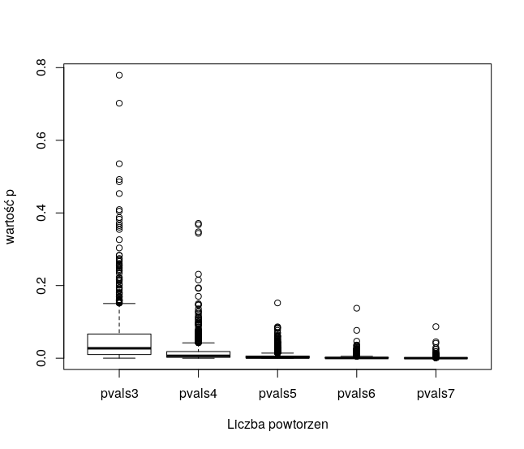

Wyniki 4

## Niech moc będzie z Tobą

- **Moc testu (moc statystyczna)** to prawdopodobieństwo niepopełnienia błędu drugiego rodzaju – nieodrzucenia hipotezy zerowej, gdy w rzeczywistości jest ona fałszywa. Im większe jest to prawdopodobieństwo, tym lepszy jest dany test jako narzędzie do różnicowania między hipotezą prawdziwą i fałszywą.
- Moc zależy bezpośrednio i przede wszystkim od poniższych czynników:
  - wielkości próby użytej w badaniu,
  - rzeczywistej wielkości efektu na tle losowej zmienności w populacji,
  - przyjętego poziomu istotności α (najczęściej 0,05).

## Pakiet *“pwr”*

- pwr.t.test(d=1, n=3, sig.level = 0.05)
  - *d* - \(\ \frac{\mu_1 - \mu_2}{\sigma}\)
  - *n* - liczba powtórzeń
  - *sig.level* - prawdopodobieństwo, że średnie są równe (\(H_0\)!)
- pwr.anona.test
- pwr.norm.test

## Pakiet *“pwr”*

```r
library(pwr)

pwr.t.test(d=1, n=3, sig.level = 0.05)
```

```
##
##      Two-sample t test power calculation
##
##               n = 3
##               d = 1
##       sig.level = 0.05
##           power = 0.1587909
##     alternative = two.sided
##
## NOTE: n is number in *each* group
```

## Pakiet *“pwr”*

```r
pwr.t.test(d=1, n=6, sig.level = 0.05)
```

```
##
##      Two-sample t test power calculation
##
##               n = 6
##               d = 1
##       sig.level = 0.05
##           power = 0.3473537
##     alternative = two.sided
##
## NOTE: n is number in *each* group
```

## Moc testu t (d = 1, sig.level = 0.05)

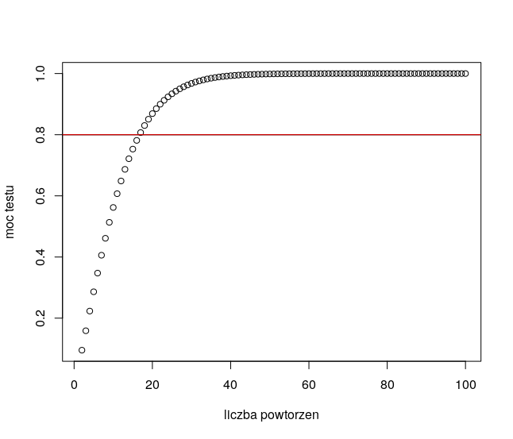

Moc testu t

## Mapa

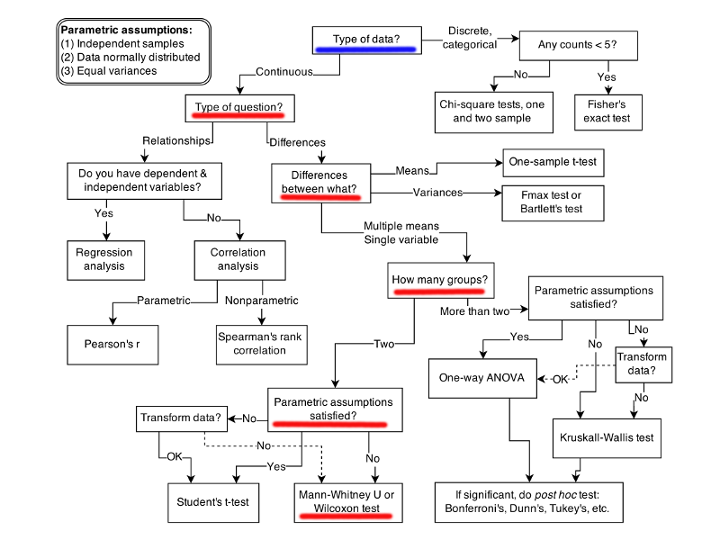

Labirynt

## Test Manna-Whitneya-Wilcoxona

- zaproponowany w latach 1945 - 1947
- obserwacje są niezależne
- zmienne można uporządkować
- **rozkłady nie muszą być normalne**

## Wpływ rodzaju gleby na długość systemu korzeniowego

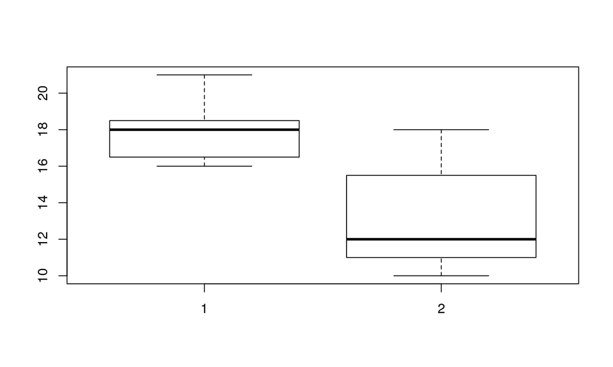

```r
gsu = c(18, 18, 21, 17, 19, 18, 16, 16) # Gleby słabo ukształtowane
gc = c(18, 12, 11, 12, 10, 11, 14, 17) # Gleby czarnoziemne
boxplot(gsu, gc)
```

## Wpływ rodzaju gleby na długość systemu korzeniowego

```r
# Gleby słabo ukształtowane (gsu)
gsu = c(18, 18, 21, 17, 19, 18, 16, 16)
# Gleby czarnoziemne (gc)
gc = c(18, 12, 11, 12, 10, 11, 14, 17)

# Porównanie
wilcox.test(gsu, gc)
```

```
##
##  Wilcoxon rank sum test with continuity correction
##
## data:  gsu and gc
## W = 57, p-value = 0.009325
## alternative hypothesis: true location shift is not equal to 0
```

## Mapa

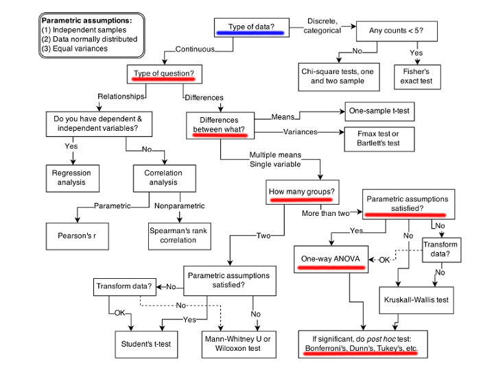

Labirynt

## Porównanie wielu grup

\(Hipoteza: \mu_{0} = \mu_{1} = \mu_{2}\)

\(P_{całkowite(3)} = prawdziwe \ jest \ pierwsze \ i \ drugie \ porównanie.\)

\(P_{całkowite(3)} = P_{1} P_{2}\)

\(P_{całkowite(n)} = \prod_{k=0}^{n-1} P\)

## Wpływ warunków eksperymentu na suchą masę roślin

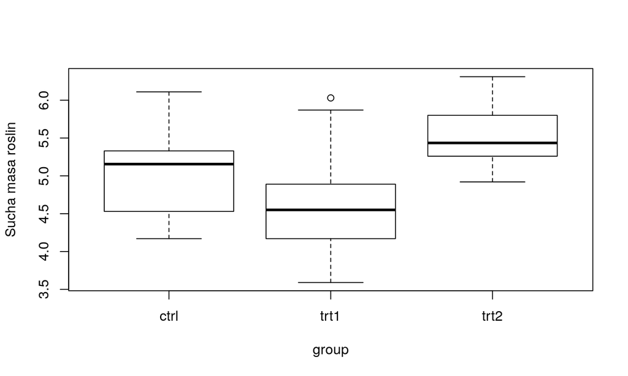

```r
data("PlantGrowth")

boxplot(weight ~ group, data = PlantGrowth,
        ylab = "Sucha masa roslin")
```

## ANOVA - przykład

```r
data("PlantGrowth")
summary(PlantGrowth)
```

```
##      weight       group
##  Min.   :3.590   ctrl:10
##  1st Qu.:4.550   trt1:10
##  Median :5.155   trt2:10
##  Mean   :5.073
##  3rd Qu.:5.530
##  Max.   :6.310
```

```r
growth_model = aov(PlantGrowth$weight ~ PlantGrowth$group)
summary(growth_model)
```

```
##                   Df Sum Sq Mean Sq F value Pr(>F)
## PlantGrowth$group  2  3.766  1.8832   4.846 0.0159 *
## Residuals         27 10.492  0.3886
## ---
## Signif. codes:  0 '***' 0.001 '**' 0.01 '*' 0.05 '.' 0.1 ' ' 1
```

## ANOVA - testy post hoc

```r
TukeyHSD(growth_model)
```

```
##   Tukey multiple comparisons of means
##     95% family-wise confidence level
##
## Fit: aov(formula = PlantGrowth$weight ~ PlantGrowth$group)
##
## $`PlantGrowth$group`
##             diff        lwr       upr     p adj
## trt1-ctrl -0.371 -1.0622161 0.3202161 0.3908711
## trt2-ctrl  0.494 -0.1972161 1.1852161 0.1979960
## trt2-trt1  0.865  0.1737839 1.5562161 0.0120064
```

## Mapa

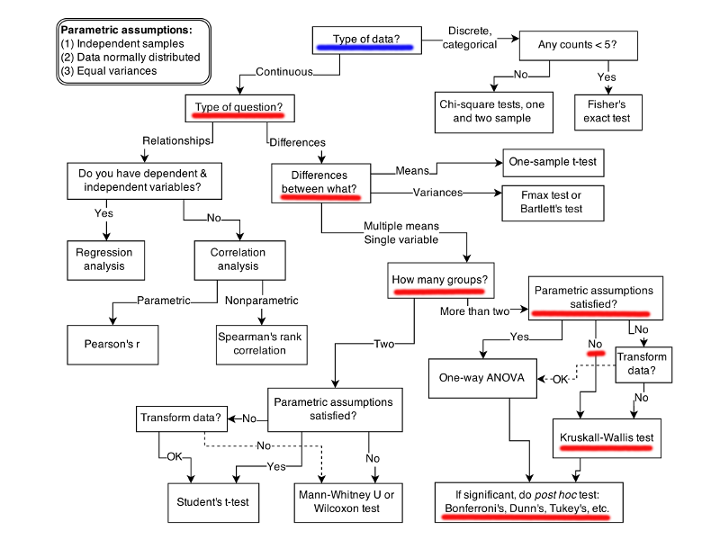

Labirynt

## Nieparametryczna wersja ANOVA - **Kruskal-Wallis**

```r
root_length <- read.csv("./root_length.csv")
summary(root_length)
```

```
##       place        root
##  dukla   :4   Min.   : 8.00
##  jarocin :4   1st Qu.:14.25
##  katowice:6   Median :20.00
##  ssacz   :4   Mean   :25.50
##               3rd Qu.:26.50
##               Max.   :66.00
```

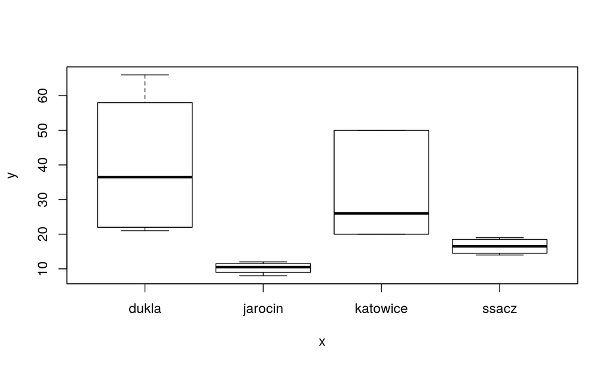

```r
plot(root_length$place, root_length$root)
```

## Nieparametryczna wersja ANOVA - **Kruskal-Wallis**

```r
kruskal.test(root ~ place, data = root_length)
```

```
##
##  Kruskal-Wallis rank sum test
##
## data:  root by place
## Kruskal-Wallis chi-squared = 13.958, df = 3, p-value = 0.002963
```

## **Kruskal-Wallis** - testy post hoc

```r
library(ggpubr)
compare_means(root ~ place, data = root_length)
```

```
## # A tibble: 6 x 8
##   .y.   group1   group2        p p.adj p.format p.signif method
##   <chr> <chr>    <chr>     <dbl> <dbl> <chr>    <chr>    <chr>
## 1 root  dukla    jarocin  0.0286 0.11  0.029    *        Wilcoxon
## 2 root  dukla    katowice 0.588  0.59  0.588    ns       Wilcoxon
## 3 root  dukla    ssacz    0.0286 0.11  0.029    *        Wilcoxon
## 4 root  jarocin  katowice 0.0136 0.082 0.014    *        Wilcoxon
## 5 root  jarocin  ssacz    0.0286 0.11  0.029    *        Wilcoxon
## 6 root  katowice ssacz    0.0136 0.082 0.014    *        Wilcoxon
```

## Mapa

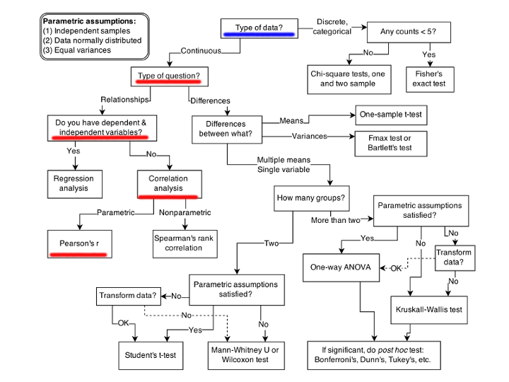

Labirynt

## Korelacja

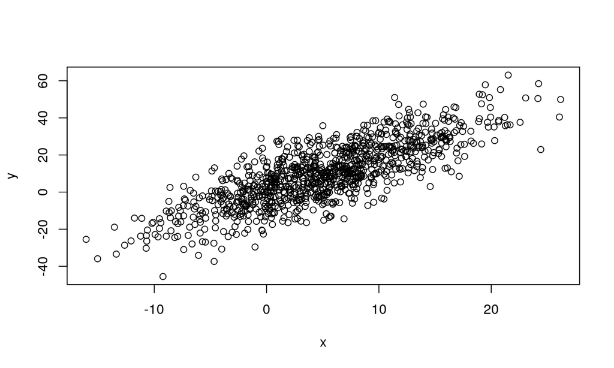

```r
x = rnorm(1000, 5, 7) # losujemy liczby
error = rnorm(1000, 0, 10) # dodajemy rozrzut
y = 2*x + error # obliczamy zmienną skorelowaną
plot(x, y)
```

## Korelacja

```r
x = rnorm(1000, 5, 7) # losujemy liczby
error = rnorm(1000, 0, 10) # dodajemy rozrzut
y = 2*x + error # obliczamy zmienną skorelowaną
plot(x, y)

cor(x,y)
cor.test(x,y)
```

## Korelacja

- Jak zmienić kierunek korelacji?
- Jak zmienić wartość R^2 ?
- Jak zwiększyć / zmniejszyć siłę korelacji?
- Zaproponuj nową funkcję *y*, zrób wykres, policz korelację.

## Korelacja wielu zmiennych

Corplot

```r
library(corrplot)
mydata = read.csv("https://wiki.q-researchsoftware.com/images/b/b9/Ownership.csv",
                  header = TRUE,
                  fileEncoding="latin1")
mydata.cor = cor(mydata, method = c("spearman"))

corrplot(mydata.cor)
```

## Mapa - regresja liniowa

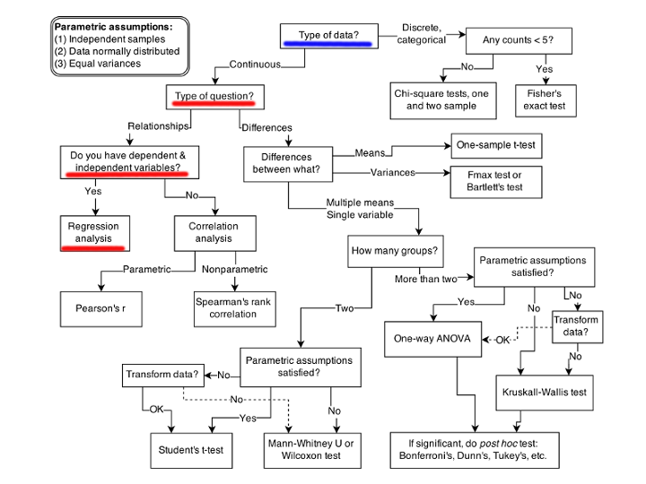

Labirynt

## Regresja liniowa

- regreja liniowa (*lm*)

\(y = X B = X_{1} \beta_{1} + X_{2} \beta_{2} + ... + X_{n} \beta_{n} + \epsilon\)

- regresja nieliniowa
- regresja uogólniona (*glm*)

## Galton

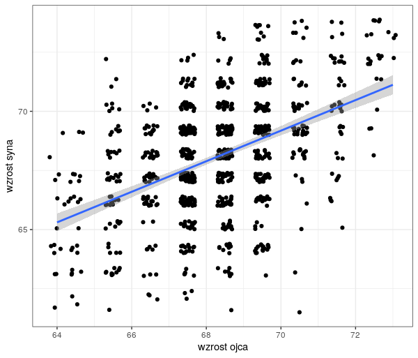

Ojcowie i dzieci

## Galton

```r
library(ggplot2) #1
library(UsingR) #2
ggplot(data = galton) + #3
  geom_jitter(aes(parent, child)) + #4
  geom_smooth(aes(parent, child), method = 'lm') + #5
  xlab("wzrost ojca") + #6
  ylab("wzrost syna") + #7
  theme_bw() #8
```

- *1, 2* - wczytuje pakiet do wyresów i pakiet z danymi,
- *3, 4* - przypisuje dane do wykresu, rozrzuca punkty o tej samej wartości (jitter)
- *5* - rysuje prostą regresji
- *6, 7, 8* - opisuje osie, formatuje wykres

## Anscombe

```r
data("anscombe")
summary(anscombe)
```

```
##        x1             x2             x3             x4
##  Min.   : 4.0   Min.   : 4.0   Min.   : 4.0   Min.   : 8
##  1st Qu.: 6.5   1st Qu.: 6.5   1st Qu.: 6.5   1st Qu.: 8
##  Median : 9.0   Median : 9.0   Median : 9.0   Median : 8
##  Mean   : 9.0   Mean   : 9.0   Mean   : 9.0   Mean   : 9
##  3rd Qu.:11.5   3rd Qu.:11.5   3rd Qu.:11.5   3rd Qu.: 8
##  Max.   :14.0   Max.   :14.0   Max.   :14.0   Max.   :19
##        y1               y2              y3              y4
##  Min.   : 4.260   Min.   :3.100   Min.   : 5.39   Min.   : 5.250
##  1st Qu.: 6.315   1st Qu.:6.695   1st Qu.: 6.25   1st Qu.: 6.170
##  Median : 7.580   Median :8.140   Median : 7.11   Median : 7.040
##  Mean   : 7.501   Mean   :7.501   Mean   : 7.50   Mean   : 7.501
##  3rd Qu.: 8.570   3rd Qu.:8.950   3rd Qu.: 7.98   3rd Qu.: 8.190
##  Max.   :10.840   Max.   :9.260   Max.   :12.74   Max.   :12.500
```

## Anscombe

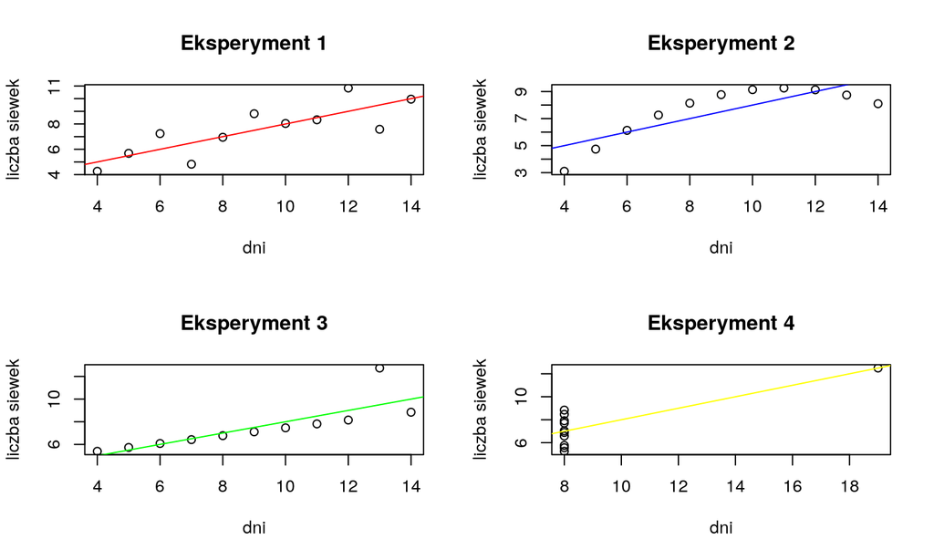

```r
data("anscombe")
par(mfrow = c(2,2))
plot(anscombe$x1, anscombe$y1, xlab = "dni", ylab = "liczba siewek", title("Eksperyment 1"))
abline(coef = lm(y1~x1, data = anscombe)$coef, col = "red")
plot(anscombe$x2, anscombe$y2, xlab = "dni", ylab = "liczba siewek", title("Eksperyment 2"))
abline(coef = lm(y2~x2, data = anscombe)$coef, col = "blue")
plot(anscombe$x3, anscombe$y3, xlab = "dni", ylab = "liczba siewek", title("Eksperyment 3"))
abline(coef = lm(y3~x3, data = anscombe)$coef, col = "green")
plot(anscombe$x4, anscombe$y4, xlab = "dni", ylab = "liczba siewek", title("Eksperyment 4"))
abline(coef = lm(y4~x4, data = anscombe)$coef, col = "yellow")
```